# Exploratory Analysis

Augene Pak, Brian Park, Joseph Altamira, Johnny Seto

### Introduction

For our exploratory analysis, we used datasets from the Center for Disease Control and Prevention and a dataset collected by the Bureau of Labor Statistics (BLS) Local Area Unemployment Statistics (LAUS) program. We decided to focus on the relationship between economic status versus cancer deaths per case and cases per population. We also focus our analysis in the West Coast of the United States: Washington, Oregon, and California.

### Distribution of Variables

```r
sex_dist
```

[interactive chart not shown]

```r
race_dist
```

[interactive chart not shown]

### Relationships between Variables

## Age-Adjusted Death Rates VS Median Household Income

For the bubble plot below, we compared the median household income in 2019 in Washington, Oregon, and California to the age adjusted death rates to understand the relationship that economic status has on the mortality rate from cancer. We used the gapminder and plotly packages to color code the states and visualize this relationship. From the visualization, we noticed higher income counties in California had a lower mortality rate than lower income counties. This may be due to the availability of better hospital’s with cancer treatments within higher income counties.

[interactive chart not shown]

## Age-Adjusted Rate of New Cancer VS Counties

The above map displays the age-adjusted rate of new cancers. We used the map functionality within ggplot to retrieve the longitudes and longitudes for the three states we were focusing on, and we merged the geographical dataset and the original comprehensive dataset to generate a choropleth map that displays lighter colors for a greater age-adjusted case rate.

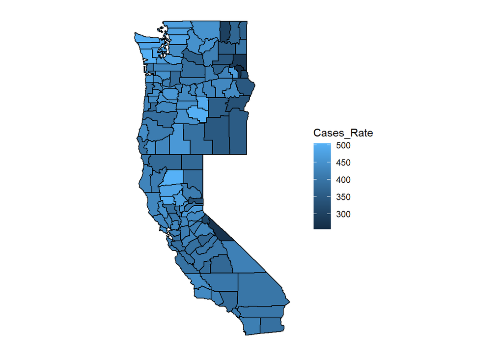